# Risk Factor Analysis

## Outcome Variable

**Outcome Variable:** haz

## Predictor Variables

**Intervention Variable:** exclfeed3

**Adjustment Set:**

- arm
- sex
- brthmon
- W_mage
- meducyrs
- feducyrs
- hhwealth_quart
- hfoodsec
- W_mhtcm
- W_mwtkg
- W_mbmi
- vagbrth
- W_gagebrth
- W_birthwt
- W_birthlen
- W_nrooms
- W_nchldlt5
- month
- W_parity
- impfloor
- impsan
- safeh20
- delta_W_mage
- delta_meducyrs
- delta_feducyrs
- delta_hhwealth_quart
- delta_hfoodsec
- delta_W_mhtcm
- delta_W_mwtkg
- delta_W_mbmi
- delta_vagbrth
- delta_W_gagebrth
- delta_W_birthwt
- delta_W_birthlen
- delta_W_nrooms
- delta_W_nchldlt5
- delta_month
- delta_W_parity
- delta_impfloor
- delta_impsan
- delta_safeh20

## Stratifying Variables

The analysis was stratified on these variable(s):

- agecat
- studyid
- country

## Data Summary

| agecat | studyid | country | exclfeed3 | n_cell | n |
| --- | --- | --- | --- | --- | --- |
| Birth | ki0047075b-MAL-ED | BANGLADESH | 1 | 138 | 215 |
| Birth | ki0047075b-MAL-ED | BANGLADESH | 0 | 77 | 215 |
| Birth | ki0047075b-MAL-ED | BRAZIL | 1 | 12 | 57 |
| Birth | ki0047075b-MAL-ED | BRAZIL | 0 | 45 | 57 |
| Birth | ki0047075b-MAL-ED | INDIA | 1 | 24 | 41 |
| Birth | ki0047075b-MAL-ED | INDIA | 0 | 17 | 41 |
| Birth | ki0047075b-MAL-ED | NEPAL | 1 | 8 | 26 |
| Birth | ki0047075b-MAL-ED | NEPAL | 0 | 18 | 26 |
| Birth | ki0047075b-MAL-ED | PERU | 1 | 49 | 223 |
| Birth | ki0047075b-MAL-ED | PERU | 0 | 174 | 223 |
| Birth | ki0047075b-MAL-ED | SOUTH AFRICA | 1 | 12 | 100 |
| Birth | ki0047075b-MAL-ED | SOUTH AFRICA | 0 | 88 | 100 |
| Birth | ki0047075b-MAL-ED | TANZANIA, UNITED REPUBLIC OF | 1 | 17 | 102 |
| Birth | ki0047075b-MAL-ED | TANZANIA, UNITED REPUBLIC OF | 0 | 85 | 102 |
| Birth | ki1000108-CMC-V-BCS-2002 | INDIA | 1 | 4 | 4 |
| Birth | ki1000108-CMC-V-BCS-2002 | INDIA | 0 | 0 | 4 |
| Birth | ki1000108-IRC | INDIA | 1 | 0 | 10 |
| Birth | ki1000108-IRC | INDIA | 0 | 10 | 10 |
| Birth | ki1000109-EE | PAKISTAN | 1 | 35 | 35 |
| Birth | ki1000109-EE | PAKISTAN | 0 | 0 | 35 |
| Birth | ki1000304b-SAS-CompFeed | INDIA | 1 | 346 | 364 |
| Birth | ki1000304b-SAS-CompFeed | INDIA | 0 | 18 | 364 |
| Birth | ki1017093b-PROVIDE | BANGLADESH | 1 | 387 | 539 |
| Birth | ki1017093b-PROVIDE | BANGLADESH | 0 | 152 | 539 |
| Birth | ki1101329-Keneba | GAMBIA | 1 | 1198 | 1356 |
| Birth | ki1101329-Keneba | GAMBIA | 0 | 158 | 1356 |
| Birth | ki1113344-GMS-Nepal | NEPAL | 1 | 380 | 458 |
| Birth | ki1113344-GMS-Nepal | NEPAL | 0 | 78 | 458 |
| Birth | kiGH5241-JiVitA-3 | BANGLADESH | 1 | 12014 | 13276 |
| Birth | kiGH5241-JiVitA-3 | BANGLADESH | 0 | 1262 | 13276 |

[output cut: 64 more lines]

The following strata were considered:

- agecat: 24 months, studyid: ki0047075b-MAL-ED, country: BANGLADESH
- agecat: 24 months, studyid: ki0047075b-MAL-ED, country: BRAZIL
- agecat: 24 months, studyid: ki0047075b-MAL-ED, country: INDIA
- agecat: 24 months, studyid: ki0047075b-MAL-ED, country: NEPAL
- agecat: 24 months, studyid: ki0047075b-MAL-ED, country: PERU
- agecat: 24 months, studyid: ki0047075b-MAL-ED, country: SOUTH AFRICA
- agecat: 24 months, studyid: ki0047075b-MAL-ED, country: TANZANIA, UNITED REPUBLIC OF
- agecat: 24 months, studyid: ki1000108-CMC-V-BCS-2002, country: INDIA
- agecat: 24 months, studyid: ki1000108-IRC, country: INDIA
- agecat: 24 months, studyid: ki1000109-EE, country: PAKISTAN
- agecat: 24 months, studyid: ki1017093b-PROVIDE, country: BANGLADESH
- agecat: 24 months, studyid: ki1101329-Keneba, country: GAMBIA
- agecat: 24 months, studyid: ki1113344-GMS-Nepal, country: NEPAL
- agecat: 24 months, studyid: kiGH5241-JiVitA-3, country: BANGLADESH
- agecat: 24 months, studyid: kiGH5241-JiVitA-4, country: BANGLADESH
- agecat: 6 months, studyid: ki0047075b-MAL-ED, country: BANGLADESH
- agecat: 6 months, studyid: ki0047075b-MAL-ED, country: BRAZIL
- agecat: 6 months, studyid: ki0047075b-MAL-ED, country: INDIA
- agecat: 6 months, studyid: ki0047075b-MAL-ED, country: NEPAL
- agecat: 6 months, studyid: ki0047075b-MAL-ED, country: PERU
- agecat: 6 months, studyid: ki0047075b-MAL-ED, country: SOUTH AFRICA
- agecat: 6 months, studyid: ki0047075b-MAL-ED, country: TANZANIA, UNITED REPUBLIC OF
- agecat: 6 months, studyid: ki1000108-CMC-V-BCS-2002, country: INDIA
- agecat: 6 months, studyid: ki1000108-IRC, country: INDIA
- agecat: 6 months, studyid: ki1000109-EE, country: PAKISTAN
- agecat: 6 months, studyid: ki1000304b-SAS-CompFeed, country: INDIA
- agecat: 6 months, studyid: ki1017093b-PROVIDE, country: BANGLADESH
- agecat: 6 months, studyid: ki1101329-Keneba, country: GAMBIA
- agecat: 6 months, studyid: ki1113344-GMS-Nepal, country: NEPAL
- agecat: 6 months, studyid: kiGH5241-JiVitA-3, country: BANGLADESH
- agecat: 6 months, studyid: kiGH5241-JiVitA-4, country: BANGLADESH
- agecat: Birth, studyid: ki0047075b-MAL-ED, country: BANGLADESH
- agecat: Birth, studyid: ki0047075b-MAL-ED, country: BRAZIL
- agecat: Birth, studyid: ki0047075b-MAL-ED, country: INDIA
- agecat: Birth, studyid: ki0047075b-MAL-ED, country: NEPAL
- agecat: Birth, studyid: ki0047075b-MAL-ED, country: PERU
- agecat: Birth, studyid: ki0047075b-MAL-ED, country: SOUTH AFRICA
- agecat: Birth, studyid: ki0047075b-MAL-ED, country: TANZANIA, UNITED REPUBLIC OF
- agecat: Birth, studyid: ki1000108-CMC-V-BCS-2002, country: INDIA
- agecat: Birth, studyid: ki1000108-IRC, country: INDIA
- agecat: Birth, studyid: ki1000109-EE, country: PAKISTAN
- agecat: Birth, studyid: ki1000304b-SAS-CompFeed, country: INDIA
- agecat: Birth, studyid: ki1017093b-PROVIDE, country: BANGLADESH
- agecat: Birth, studyid: ki1101329-Keneba, country: GAMBIA
- agecat: Birth, studyid: ki1113344-GMS-Nepal, country: NEPAL
- agecat: Birth, studyid: kiGH5241-JiVitA-3, country: BANGLADESH
- agecat: Birth, studyid: kiGH5241-JiVitA-4, country: BANGLADESH

### Dropped Strata

- agecat: Birth, studyid: ki1000108-CMC-V-BCS-2002, country: INDIA
- agecat: Birth, studyid: ki1000108-IRC, country: INDIA
- agecat: Birth, studyid: ki1000109-EE, country: PAKISTAN
- agecat: 6 months, studyid: ki1000108-CMC-V-BCS-2002, country: INDIA
- agecat: 6 months, studyid: ki1000108-IRC, country: INDIA
- agecat: 6 months, studyid: ki1000109-EE, country: PAKISTAN
- agecat: 24 months, studyid: ki1000108-CMC-V-BCS-2002, country: INDIA
- agecat: 24 months, studyid: ki1000108-IRC, country: INDIA
- agecat: 24 months, studyid: ki1000109-EE, country: PAKISTAN

## Methods Detail

We’re interested in the causal parameters $E[Y_a]$ for all values of $a \in \mathcal{A}$. These parameters represent the mean outcome if, possibly contrary to fact, we intervened to set all units to have $A=a$. Under the randomization and positivity assumptions, these are identified by the statistical parameters $\psi_a=E_W[E_{Y|A,W}(Y|A=a,W)]$. In addition, we’re interested in the mean of $Y$, $E[Y]$ under no intervention (the observed mean). We will estimate these parameters by using SuperLearner to fit the relevant likelihood factors – $E_{Y|A,W}(Y|A=a,W)$ and $p(A=a|W)$, and then updating our likelihood fit using a joint TMLE.

For unadjusted analyses ($W=\{\}$), initial likelihoods were estimated using Lrnr_glm to estimate the simple $E(Y|A)$ and Lrnr_mean to estimate $p(A)$. For adjusted analyses, a small library containing Lrnr_glmnet, Lrnr_xgboost, and Lrnr_mean was used.

Having estimated these parameters, we will then use the delta method to estimate relative risks and attributable risks relative to a prespecified baseline level of $A$.

# Results Detail

## Results Plots

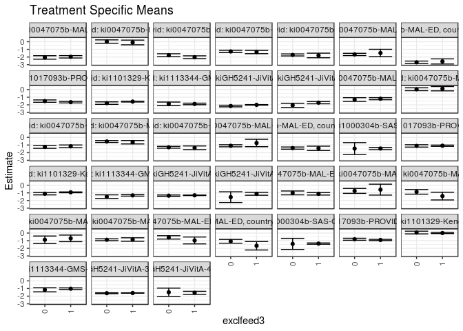

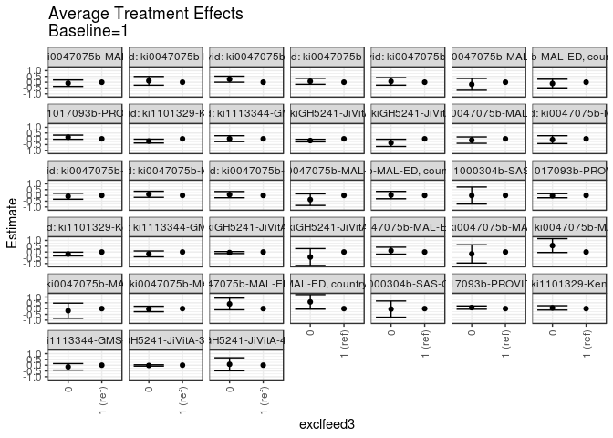

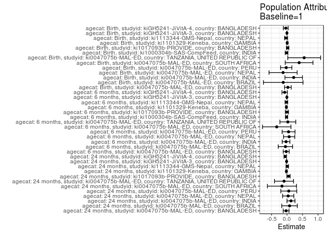

## Results Table

### Parameter: TSM

| agecat | studyid | country | intervention_level | baseline_level | estimate | ci_lower | ci_upper |
| --- | --- | --- | --- | --- | --- | --- | --- |
| Birth | ki0047075b-MAL-ED | BANGLADESH | 1 | NA | -1.1230985 | -1.2841155 | -0.9620816 |
| Birth | ki0047075b-MAL-ED | BANGLADESH | 0 | NA | -1.0081994 | -1.2610679 | -0.7553309 |
| Birth | ki0047075b-MAL-ED | BRAZIL | 1 | NA | -0.5775625 | -1.2897560 | 0.1346309 |
| Birth | ki0047075b-MAL-ED | BRAZIL | 0 | NA | -0.7427735 | -1.0668969 | -0.4186501 |
| Birth | ki0047075b-MAL-ED | INDIA | 1 | NA | -1.4231140 | -1.9304347 | -0.9157933 |
| Birth | ki0047075b-MAL-ED | INDIA | 0 | NA | -0.8689138 | -1.1703349 | -0.5674927 |
| Birth | ki0047075b-MAL-ED | NEPAL | 1 | NA | -0.6962500 | -1.1273498 | -0.2651502 |
| Birth | ki0047075b-MAL-ED | NEPAL | 0 | NA | -0.8800000 | -1.3706027 | -0.3893973 |
| Birth | ki0047075b-MAL-ED | PERU | 1 | NA | -0.8490703 | -1.0752151 | -0.6229254 |
| Birth | ki0047075b-MAL-ED | PERU | 0 | NA | -0.8794955 | -1.0027226 | -0.7562684 |
| Birth | ki0047075b-MAL-ED | SOUTH AFRICA | 1 | NA | -0.9711660 | -1.4223408 | -0.5199912 |
| Birth | ki0047075b-MAL-ED | SOUTH AFRICA | 0 | NA | -0.5692996 | -0.7875437 | -0.3510556 |
| Birth | ki0047075b-MAL-ED | TANZANIA, UNITED REPUBLIC OF | 1 | NA | -1.6630764 | -2.2185456 | -1.1076072 |
| Birth | ki0047075b-MAL-ED | TANZANIA, UNITED REPUBLIC OF | 0 | NA | -1.0830538 | -1.3323405 | -0.8337672 |
| Birth | ki1000304b-SAS-CompFeed | INDIA | 1 | NA | -1.3791852 | -1.4632653 | -1.2951052 |
| Birth | ki1000304b-SAS-CompFeed | INDIA | 0 | NA | -1.4188476 | -2.1434587 | -0.6942365 |
| Birth | ki1017093b-PROVIDE | BANGLADESH | 1 | NA | -0.9053743 | -0.9854424 | -0.8253063 |
| Birth | ki1017093b-PROVIDE | BANGLADESH | 0 | NA | -0.8160096 | -0.9480805 | -0.6839388 |
| Birth | ki1101329-Keneba | GAMBIA | 1 | NA | 0.0037475 | -0.0693656 | 0.0768606 |
| Birth | ki1101329-Keneba | GAMBIA | 0 | NA | 0.0649152 | -0.1136939 | 0.2435244 |
| Birth | ki1113344-GMS-Nepal | NEPAL | 1 | NA | -1.0246066 | -1.1316256 | -0.9175877 |
| Birth | ki1113344-GMS-Nepal | NEPAL | 0 | NA | -1.1677310 | -1.4310148 | -0.9044471 |
| Birth | kiGH5241-JiVitA-3 | BANGLADESH | 1 | NA | -1.5899535 | -1.6135892 | -1.5663179 |
| Birth | kiGH5241-JiVitA-3 | BANGLADESH | 0 | NA | -1.6135376 | -1.6685359 | -1.5585393 |
| Birth | kiGH5241-JiVitA-4 | BANGLADESH | 1 | NA | -1.5668819 | -1.7686140 | -1.3651498 |
| Birth | kiGH5241-JiVitA-4 | BANGLADESH | 0 | NA | -1.4899311 | -2.0288629 | -0.9509993 |
| 6 months | ki0047075b-MAL-ED | BANGLADESH | 1 | NA | -1.1982099 | -1.3323213 | -1.0640984 |
| 6 months | ki0047075b-MAL-ED | BANGLADESH | 0 | NA | -1.3097545 | -1.5508788 | -1.0686302 |
| 6 months | ki0047075b-MAL-ED | BRAZIL | 1 | NA | 0.1122309 | -0.1700612 | 0.3945229 |
| 6 months | ki0047075b-MAL-ED | BRAZIL | 0 | NA | 0.0402546 | -0.1486467 | 0.2291560 |
| 6 months | ki0047075b-MAL-ED | INDIA | 1 | NA | -1.1683733 | -1.3414410 | -0.9953056 |
| 6 months | ki0047075b-MAL-ED | INDIA | 0 | NA | -1.2417823 | -1.4317718 | -1.0517929 |
| 6 months | ki0047075b-MAL-ED | NEPAL | 1 | NA | -0.6319358 | -0.8581773 | -0.4056942 |
| 6 months | ki0047075b-MAL-ED | NEPAL | 0 | NA | -0.5355739 | -0.6659870 | -0.4051609 |
| 6 months | ki0047075b-MAL-ED | PERU | 1 | NA | -1.3615787 | -1.6009805 | -1.1221768 |
| 6 months | ki0047075b-MAL-ED | PERU | 0 | NA | -1.2941602 | -1.4151288 | -1.1731916 |
| 6 months | ki0047075b-MAL-ED | SOUTH AFRICA | 1 | NA | -0.7342423 | -1.2180347 | -0.2504499 |
| 6 months | ki0047075b-MAL-ED | SOUTH AFRICA | 0 | NA | -1.0989592 | -1.2339903 | -0.9639282 |
| 6 months | ki0047075b-MAL-ED | TANZANIA, UNITED REPUBLIC OF | 1 | NA | -1.4301448 | -1.7125001 | -1.1477895 |
| 6 months | ki0047075b-MAL-ED | TANZANIA, UNITED REPUBLIC OF | 0 | NA | -1.4008248 | -1.5447831 | -1.2568665 |
| 6 months | ki1000304b-SAS-CompFeed | INDIA | 1 | NA | -1.4549959 | -1.6008850 | -1.3091069 |
| 6 months | ki1000304b-SAS-CompFeed | INDIA | 0 | NA | -1.4654856 | -2.2428805 | -0.6880907 |
| 6 months | ki1017093b-PROVIDE | BANGLADESH | 1 | NA | -1.0891096 | -1.1729727 | -1.0052465 |
| 6 months | ki1017093b-PROVIDE | BANGLADESH | 0 | NA | -1.1167879 | -1.2718826 | -0.9616931 |
| 6 months | ki1101329-Keneba | GAMBIA | 1 | NA | -0.9289615 | -0.9828589 | -0.8750641 |
| 6 months | ki1101329-Keneba | GAMBIA | 0 | NA | -1.1097949 | -1.2642444 | -0.9553454 |
| 6 months | ki1113344-GMS-Nepal | NEPAL | 1 | NA | -1.3300178 | -1.4249804 | -1.2350552 |
| 6 months | ki1113344-GMS-Nepal | NEPAL | 0 | NA | -1.4965706 | -1.7325118 | -1.2606294 |
| 6 months | kiGH5241-JiVitA-3 | BANGLADESH | 1 | NA | -1.3197150 | -1.3488822 | -1.2905478 |
| 6 months | kiGH5241-JiVitA-3 | BANGLADESH | 0 | NA | -1.3678191 | -1.4527092 | -1.2829290 |
| 6 months | kiGH5241-JiVitA-4 | BANGLADESH | 1 | NA | -1.1233771 | -1.3116861 | -0.9350681 |
| 6 months | kiGH5241-JiVitA-4 | BANGLADESH | 0 | NA | -1.5590145 | -2.2615736 | -0.8564555 |
| 24 months | ki0047075b-MAL-ED | BANGLADESH | 1 | NA | -1.9723344 | -2.1286362 | -1.8160326 |
| 24 months | ki0047075b-MAL-ED | BANGLADESH | 0 | NA | -2.0583472 | -2.2855353 | -1.8311590 |
| 24 months | ki0047075b-MAL-ED | BRAZIL | 1 | NA | -0.0979705 | -0.4060723 | 0.2101313 |
| 24 months | ki0047075b-MAL-ED | BRAZIL | 0 | NA | 0.0210595 | -0.1987838 | 0.2409028 |
| 24 months | ki0047075b-MAL-ED | INDIA | 1 | NA | -2.0274628 | -2.2078871 | -1.8470385 |
| 24 months | ki0047075b-MAL-ED | INDIA | 0 | NA | -1.7692473 | -1.9621741 | -1.5763205 |
| 24 months | ki0047075b-MAL-ED | NEPAL | 1 | NA | -1.3484985 | -1.5611410 | -1.1358560 |
| 24 months | ki0047075b-MAL-ED | NEPAL | 0 | NA | -1.2699904 | -1.4163844 | -1.1235964 |
| 24 months | ki0047075b-MAL-ED | PERU | 1 | NA | -1.7981332 | -2.0971838 | -1.4990827 |
| 24 months | ki0047075b-MAL-ED | PERU | 0 | NA | -1.7268474 | -1.8593026 | -1.5943923 |
| 24 months | ki0047075b-MAL-ED | SOUTH AFRICA | 1 | NA | -1.4788610 | -1.9649457 | -0.9927763 |
| 24 months | ki0047075b-MAL-ED | SOUTH AFRICA | 0 | NA | -1.6647669 | -1.8105696 | -1.5189643 |
| 24 months | ki0047075b-MAL-ED | TANZANIA, UNITED REPUBLIC OF | 1 | NA | -2.5807533 | -2.9173120 | -2.2441946 |
| 24 months | ki0047075b-MAL-ED | TANZANIA, UNITED REPUBLIC OF | 0 | NA | -2.6944052 | -2.8560732 | -2.5327372 |
| 24 months | ki1017093b-PROVIDE | BANGLADESH | 1 | NA | -1.6506892 | -1.7482671 | -1.5531113 |
| 24 months | ki1017093b-PROVIDE | BANGLADESH | 0 | NA | -1.5114943 | -1.6645785 | -1.3584100 |
| 24 months | ki1101329-Keneba | GAMBIA | 1 | NA | -1.5765838 | -1.6334042 | -1.5197635 |
| 24 months | ki1101329-Keneba | GAMBIA | 0 | NA | -1.7735226 | -1.9338866 | -1.6131586 |
| 24 months | ki1113344-GMS-Nepal | NEPAL | 1 | NA | -1.8830019 | -1.9847132 | -1.7812905 |
| 24 months | ki1113344-GMS-Nepal | NEPAL | 0 | NA | -1.8704389 | -2.1050582 | -1.6358196 |
| 24 months | kiGH5241-JiVitA-3 | BANGLADESH | 1 | NA | -2.0048539 | -2.0426645 | -1.9670434 |
| 24 months | kiGH5241-JiVitA-3 | BANGLADESH | 0 | NA | -2.1552076 | -2.2628101 | -2.0476052 |
| 24 months | kiGH5241-JiVitA-4 | BANGLADESH | 1 | NA | -1.7144611 | -1.8621565 | -1.5667658 |
| 24 months | kiGH5241-JiVitA-4 | BANGLADESH | 0 | NA | -2.0645774 | -2.3371514 | -1.7920035 |

### Parameter: E(Y)

| agecat | studyid | country | intervention_level | baseline_level | estimate | ci_lower | ci_upper |
| --- | --- | --- | --- | --- | --- | --- | --- |
| Birth | ki0047075b-MAL-ED | BANGLADESH | NA | NA | -1.0949767 | -1.2319917 | -0.9579618 |
| Birth | ki0047075b-MAL-ED | BRAZIL | NA | NA | -0.6996491 | -0.9856018 | -0.4136965 |
| Birth | ki0047075b-MAL-ED | INDIA | NA | NA | -1.2075610 | -1.5261540 | -0.8889679 |
| Birth | ki0047075b-MAL-ED | NEPAL | NA | NA | -0.8234615 | -1.1896049 | -0.4573182 |
| Birth | ki0047075b-MAL-ED | PERU | NA | NA | -0.8753812 | -0.9932108 | -0.7575515 |
| Birth | ki0047075b-MAL-ED | SOUTH AFRICA | NA | NA | -0.5797000 | -0.7788298 | -0.3805702 |
| Birth | ki0047075b-MAL-ED | TANZANIA, UNITED REPUBLIC OF | NA | NA | -1.1086275 | -1.3310338 | -0.8862211 |
| Birth | ki1000304b-SAS-CompFeed | INDIA | NA | NA | -1.3937088 | -1.5095039 | -1.2779137 |
| Birth | ki1017093b-PROVIDE | BANGLADESH | NA | NA | -0.8851020 | -0.9601332 | -0.8100709 |
| Birth | ki1101329-Keneba | GAMBIA | NA | NA | 0.0098304 | -0.0597854 | 0.0794461 |
| Birth | ki1113344-GMS-Nepal | NEPAL | NA | NA | -1.0555240 | -1.1550843 | -0.9559638 |
| Birth | kiGH5241-JiVitA-3 | BANGLADESH | NA | NA | -1.5928457 | -1.6158667 | -1.5698248 |
| Birth | kiGH5241-JiVitA-4 | BANGLADESH | NA | NA | -1.6073276 | -1.8105798 | -1.4040753 |
| 6 months | ki0047075b-MAL-ED | BANGLADESH | NA | NA | -1.2242918 | -1.3439424 | -1.1046413 |
| 6 months | ki0047075b-MAL-ED | BRAZIL | NA | NA | 0.0609091 | -0.0944768 | 0.2162950 |
| 6 months | ki0047075b-MAL-ED | INDIA | NA | NA | -1.2002381 | -1.3274929 | -1.0729833 |
| 6 months | ki0047075b-MAL-ED | NEPAL | NA | NA | -0.5634068 | -0.6769687 | -0.4498449 |
| 6 months | ki0047075b-MAL-ED | PERU | NA | NA | -1.3108735 | -1.4182407 | -1.2035062 |
| 6 months | ki0047075b-MAL-ED | SOUTH AFRICA | NA | NA | -1.0662227 | -1.1965862 | -0.9358591 |
| 6 months | ki0047075b-MAL-ED | TANZANIA, UNITED REPUBLIC OF | NA | NA | -1.4030503 | -1.5292443 | -1.2768563 |
| 6 months | ki1000304b-SAS-CompFeed | INDIA | NA | NA | -1.4697236 | -1.6333919 | -1.3060553 |
| 6 months | ki1017093b-PROVIDE | BANGLADESH | NA | NA | -1.0916915 | -1.1661176 | -1.0172654 |
| 6 months | ki1101329-Keneba | GAMBIA | NA | NA | -0.9489317 | -1.0001696 | -0.8976937 |
| 6 months | ki1113344-GMS-Nepal | NEPAL | NA | NA | -1.3499849 | -1.4387386 | -1.2612312 |
| 6 months | kiGH5241-JiVitA-3 | BANGLADESH | NA | NA | -1.3240051 | -1.3526414 | -1.2953689 |
| 6 months | kiGH5241-JiVitA-4 | BANGLADESH | NA | NA | -1.1994318 | -1.3808291 | -1.0180345 |
| 24 months | ki0047075b-MAL-ED | BANGLADESH | NA | NA | -2.0016585 | -2.1303297 | -1.8729874 |
| 24 months | ki0047075b-MAL-ED | BRAZIL | NA | NA | -0.0162939 | -0.1929098 | 0.1603221 |
| 24 months | ki0047075b-MAL-ED | INDIA | NA | NA | -1.8994059 | -2.0346781 | -1.7641337 |
| 24 months | ki0047075b-MAL-ED | NEPAL | NA | NA | -1.3109318 | -1.4313748 | -1.1904888 |
| 24 months | ki0047075b-MAL-ED | PERU | NA | NA | -1.7412963 | -1.8630698 | -1.6195228 |
| 24 months | ki0047075b-MAL-ED | SOUTH AFRICA | NA | NA | -1.6424525 | -1.7808926 | -1.5040124 |
| 24 months | ki0047075b-MAL-ED | TANZANIA, UNITED REPUBLIC OF | NA | NA | -2.6768207 | -2.8213178 | -2.5323235 |
| 24 months | ki1017093b-PROVIDE | BANGLADESH | NA | NA | -1.6024221 | -1.6857420 | -1.5191023 |
| 24 months | ki1101329-Keneba | GAMBIA | NA | NA | -1.5961170 | -1.6505261 | -1.5417080 |
| 24 months | ki1113344-GMS-Nepal | NEPAL | NA | NA | -1.8752995 | -1.9688053 | -1.7817937 |
| 24 months | kiGH5241-JiVitA-3 | BANGLADESH | NA | NA | -2.0187325 | -2.0554682 | -1.9819968 |
| 24 months | kiGH5241-JiVitA-4 | BANGLADESH | NA | NA | -1.7726490 | -1.9111913 | -1.6341067 |

### Parameter: ATE

| agecat | studyid | country | intervention_level | baseline_level | estimate | ci_lower | ci_upper |
| --- | --- | --- | --- | --- | --- | --- | --- |
| Birth | ki0047075b-MAL-ED | BANGLADESH | 1 | 1 | 0.0000000 | 0.0000000 | 0.0000000 |
| Birth | ki0047075b-MAL-ED | BANGLADESH | 0 | 1 | 0.1148991 | -0.1861581 | 0.4159563 |
| Birth | ki0047075b-MAL-ED | BRAZIL | 1 | 1 | 0.0000000 | 0.0000000 | 0.0000000 |
| Birth | ki0047075b-MAL-ED | BRAZIL | 0 | 1 | -0.1652110 | -0.9571333 | 0.6267113 |
| Birth | ki0047075b-MAL-ED | INDIA | 1 | 1 | 0.0000000 | 0.0000000 | 0.0000000 |
| Birth | ki0047075b-MAL-ED | INDIA | 0 | 1 | 0.5542002 | -0.0445156 | 1.1529161 |
| Birth | ki0047075b-MAL-ED | NEPAL | 1 | 1 | 0.0000000 | 0.0000000 | 0.0000000 |
| Birth | ki0047075b-MAL-ED | NEPAL | 0 | 1 | -0.1837500 | -0.8368488 | 0.4693488 |
| Birth | ki0047075b-MAL-ED | PERU | 1 | 1 | 0.0000000 | 0.0000000 | 0.0000000 |
| Birth | ki0047075b-MAL-ED | PERU | 0 | 1 | -0.0304253 | -0.2649223 | 0.2040718 |
| Birth | ki0047075b-MAL-ED | SOUTH AFRICA | 1 | 1 | 0.0000000 | 0.0000000 | 0.0000000 |
| Birth | ki0047075b-MAL-ED | SOUTH AFRICA | 0 | 1 | 0.4018663 | -0.1020836 | 0.9058163 |
| Birth | ki0047075b-MAL-ED | TANZANIA, UNITED REPUBLIC OF | 1 | 1 | 0.0000000 | 0.0000000 | 0.0000000 |
| Birth | ki0047075b-MAL-ED | TANZANIA, UNITED REPUBLIC OF | 0 | 1 | 0.5800226 | -0.0441137 | 1.2041588 |
| Birth | ki1000304b-SAS-CompFeed | INDIA | 1 | 1 | 0.0000000 | 0.0000000 | 0.0000000 |
| Birth | ki1000304b-SAS-CompFeed | INDIA | 0 | 1 | -0.0396624 | -0.7382457 | 0.6589209 |
| Birth | ki1017093b-PROVIDE | BANGLADESH | 1 | 1 | 0.0000000 | 0.0000000 | 0.0000000 |
| Birth | ki1017093b-PROVIDE | BANGLADESH | 0 | 1 | 0.0893647 | -0.0494453 | 0.2281747 |
| Birth | ki1101329-Keneba | GAMBIA | 1 | 1 | 0.0000000 | 0.0000000 | 0.0000000 |
| Birth | ki1101329-Keneba | GAMBIA | 0 | 1 | 0.0611678 | -0.1244819 | 0.2468174 |
| Birth | ki1113344-GMS-Nepal | NEPAL | 1 | 1 | 0.0000000 | 0.0000000 | 0.0000000 |
| Birth | ki1113344-GMS-Nepal | NEPAL | 0 | 1 | -0.1431243 | -0.4279063 | 0.1416576 |
| Birth | kiGH5241-JiVitA-3 | BANGLADESH | 1 | 1 | 0.0000000 | 0.0000000 | 0.0000000 |
| Birth | kiGH5241-JiVitA-3 | BANGLADESH | 0 | 1 | -0.0235841 | -0.0788522 | 0.0316841 |
| Birth | kiGH5241-JiVitA-4 | BANGLADESH | 1 | 1 | 0.0000000 | 0.0000000 | 0.0000000 |
| Birth | kiGH5241-JiVitA-4 | BANGLADESH | 0 | 1 | 0.0769508 | -0.4822604 | 0.6361619 |
| 6 months | ki0047075b-MAL-ED | BANGLADESH | 1 | 1 | 0.0000000 | 0.0000000 | 0.0000000 |
| 6 months | ki0047075b-MAL-ED | BANGLADESH | 0 | 1 | -0.1115446 | -0.3885308 | 0.1654416 |
| 6 months | ki0047075b-MAL-ED | BRAZIL | 1 | 1 | 0.0000000 | 0.0000000 | 0.0000000 |
| 6 months | ki0047075b-MAL-ED | BRAZIL | 0 | 1 | -0.0719762 | -0.4127613 | 0.2688088 |
| 6 months | ki0047075b-MAL-ED | INDIA | 1 | 1 | 0.0000000 | 0.0000000 | 0.0000000 |
| 6 months | ki0047075b-MAL-ED | INDIA | 0 | 1 | -0.0734090 | -0.3318187 | 0.1850007 |
| 6 months | ki0047075b-MAL-ED | NEPAL | 1 | 1 | 0.0000000 | 0.0000000 | 0.0000000 |
| 6 months | ki0047075b-MAL-ED | NEPAL | 0 | 1 | 0.0963618 | -0.1651844 | 0.3579080 |
| 6 months | ki0047075b-MAL-ED | PERU | 1 | 1 | 0.0000000 | 0.0000000 | 0.0000000 |
| 6 months | ki0047075b-MAL-ED | PERU | 0 | 1 | 0.0674185 | -0.2010816 | 0.3359186 |
| 6 months | ki0047075b-MAL-ED | SOUTH AFRICA | 1 | 1 | 0.0000000 | 0.0000000 | 0.0000000 |
| 6 months | ki0047075b-MAL-ED | SOUTH AFRICA | 0 | 1 | -0.3647169 | -0.8669203 | 0.1374864 |
| 6 months | ki0047075b-MAL-ED | TANZANIA, UNITED REPUBLIC OF | 1 | 1 | 0.0000000 | 0.0000000 | 0.0000000 |
| 6 months | ki0047075b-MAL-ED | TANZANIA, UNITED REPUBLIC OF | 0 | 1 | 0.0293200 | -0.2882832 | 0.3469231 |
| 6 months | ki1000304b-SAS-CompFeed | INDIA | 1 | 1 | 0.0000000 | 0.0000000 | 0.0000000 |
| 6 months | ki1000304b-SAS-CompFeed | INDIA | 0 | 1 | -0.0104897 | -0.7471588 | 0.7261794 |
| 6 months | ki1017093b-PROVIDE | BANGLADESH | 1 | 1 | 0.0000000 | 0.0000000 | 0.0000000 |
| 6 months | ki1017093b-PROVIDE | BANGLADESH | 0 | 1 | -0.0276783 | -0.2041643 | 0.1488078 |
| 6 months | ki1101329-Keneba | GAMBIA | 1 | 1 | 0.0000000 | 0.0000000 | 0.0000000 |
| 6 months | ki1101329-Keneba | GAMBIA | 0 | 1 | -0.1808334 | -0.3438088 | -0.0178580 |
| 6 months | ki1113344-GMS-Nepal | NEPAL | 1 | 1 | 0.0000000 | 0.0000000 | 0.0000000 |
| 6 months | ki1113344-GMS-Nepal | NEPAL | 0 | 1 | -0.1665528 | -0.4204927 | 0.0873871 |
| 6 months | kiGH5241-JiVitA-3 | BANGLADESH | 1 | 1 | 0.0000000 | 0.0000000 | 0.0000000 |
| 6 months | kiGH5241-JiVitA-3 | BANGLADESH | 0 | 1 | -0.0481041 | -0.1340494 | 0.0378412 |
| 6 months | kiGH5241-JiVitA-4 | BANGLADESH | 1 | 1 | 0.0000000 | 0.0000000 | 0.0000000 |
| 6 months | kiGH5241-JiVitA-4 | BANGLADESH | 0 | 1 | -0.4356374 | -1.1633373 | 0.2920625 |
| 24 months | ki0047075b-MAL-ED | BANGLADESH | 1 | 1 | 0.0000000 | 0.0000000 | 0.0000000 |
| 24 months | ki0047075b-MAL-ED | BANGLADESH | 0 | 1 | -0.0860128 | -0.3619780 | 0.1899524 |
| 24 months | ki0047075b-MAL-ED | BRAZIL | 1 | 1 | 0.0000000 | 0.0000000 | 0.0000000 |
| 24 months | ki0047075b-MAL-ED | BRAZIL | 0 | 1 | 0.1190301 | -0.2573155 | 0.4953756 |
| 24 months | ki0047075b-MAL-ED | INDIA | 1 | 1 | 0.0000000 | 0.0000000 | 0.0000000 |
| 24 months | ki0047075b-MAL-ED | INDIA | 0 | 1 | 0.2582155 | -0.0026485 | 0.5190794 |
| 24 months | ki0047075b-MAL-ED | NEPAL | 1 | 1 | 0.0000000 | 0.0000000 | 0.0000000 |
| 24 months | ki0047075b-MAL-ED | NEPAL | 0 | 1 | 0.0785082 | -0.1805603 | 0.3375766 |
| 24 months | ki0047075b-MAL-ED | PERU | 1 | 1 | 0.0000000 | 0.0000000 | 0.0000000 |
| 24 months | ki0047075b-MAL-ED | PERU | 0 | 1 | 0.0712858 | -0.2561488 | 0.3987204 |
| 24 months | ki0047075b-MAL-ED | SOUTH AFRICA | 1 | 1 | 0.0000000 | 0.0000000 | 0.0000000 |
| 24 months | ki0047075b-MAL-ED | SOUTH AFRICA | 0 | 1 | -0.1859059 | -0.6952462 | 0.3234343 |
| 24 months | ki0047075b-MAL-ED | TANZANIA, UNITED REPUBLIC OF | 1 | 1 | 0.0000000 | 0.0000000 | 0.0000000 |
| 24 months | ki0047075b-MAL-ED | TANZANIA, UNITED REPUBLIC OF | 0 | 1 | -0.1136519 | -0.4870407 | 0.2597369 |
| 24 months | ki1017093b-PROVIDE | BANGLADESH | 1 | 1 | 0.0000000 | 0.0000000 | 0.0000000 |
| 24 months | ki1017093b-PROVIDE | BANGLADESH | 0 | 1 | 0.1391949 | -0.0403000 | 0.3186898 |
| 24 months | ki1101329-Keneba | GAMBIA | 1 | 1 | 0.0000000 | 0.0000000 | 0.0000000 |
| 24 months | ki1101329-Keneba | GAMBIA | 0 | 1 | -0.1969387 | -0.3642496 | -0.0296278 |
| 24 months | ki1113344-GMS-Nepal | NEPAL | 1 | 1 | 0.0000000 | 0.0000000 | 0.0000000 |
| 24 months | ki1113344-GMS-Nepal | NEPAL | 0 | 1 | 0.0125629 | -0.2423130 | 0.2674389 |
| 24 months | kiGH5241-JiVitA-3 | BANGLADESH | 1 | 1 | 0.0000000 | 0.0000000 | 0.0000000 |
| 24 months | kiGH5241-JiVitA-3 | BANGLADESH | 0 | 1 | -0.1503537 | -0.2606677 | -0.0400398 |
| 24 months | kiGH5241-JiVitA-4 | BANGLADESH | 1 | 1 | 0.0000000 | 0.0000000 | 0.0000000 |
| 24 months | kiGH5241-JiVitA-4 | BANGLADESH | 0 | 1 | -0.3501163 | -0.6615928 | -0.0386399 |

### Parameter: PAR

| agecat | studyid | country | intervention_level | baseline_level | estimate | ci_lower | ci_upper |
| --- | --- | --- | --- | --- | --- | --- | --- |
| Birth | ki0047075b-MAL-ED | BANGLADESH | 1 | NA | 0.0281218 | -0.0800402 | 0.1362837 |
| Birth | ki0047075b-MAL-ED | BRAZIL | 1 | NA | -0.1220866 | -0.7605439 | 0.5163707 |
| Birth | ki0047075b-MAL-ED | INDIA | 1 | NA | 0.2155530 | -0.0673169 | 0.4984230 |
| Birth | ki0047075b-MAL-ED | NEPAL | 1 | NA | -0.1272115 | -0.5805774 | 0.3261543 |
| Birth | ki0047075b-MAL-ED | PERU | 1 | NA | -0.0263109 | -0.2085167 | 0.1558949 |
| Birth | ki0047075b-MAL-ED | SOUTH AFRICA | 1 | NA | 0.3914660 | -0.0572974 | 0.8402294 |
| Birth | ki0047075b-MAL-ED | TANZANIA, UNITED REPUBLIC OF | 1 | NA | 0.5544490 | 0.0258664 | 1.0830316 |
| Birth | ki1000304b-SAS-CompFeed | INDIA | 1 | NA | -0.0145236 | -0.0577567 | 0.0287095 |
| Birth | ki1017093b-PROVIDE | BANGLADESH | 1 | NA | 0.0202723 | -0.0191480 | 0.0596926 |
| Birth | ki1101329-Keneba | GAMBIA | 1 | NA | 0.0060829 | -0.0146484 | 0.0268142 |
| Birth | ki1113344-GMS-Nepal | NEPAL | 1 | NA | -0.0309174 | -0.0799545 | 0.0181197 |
| Birth | kiGH5241-JiVitA-3 | BANGLADESH | 1 | NA | -0.0028922 | -0.0081545 | 0.0023701 |
| Birth | kiGH5241-JiVitA-4 | BANGLADESH | 1 | NA | -0.0404457 | -0.1181309 | 0.0372395 |
| 6 months | ki0047075b-MAL-ED | BANGLADESH | 1 | NA | -0.0260820 | -0.1220347 | 0.0698707 |
| 6 months | ki0047075b-MAL-ED | BRAZIL | 1 | NA | -0.0513218 | -0.2837974 | 0.1811538 |
| 6 months | ki0047075b-MAL-ED | INDIA | 1 | NA | -0.0318648 | -0.1558166 | 0.0920870 |
| 6 months | ki0047075b-MAL-ED | NEPAL | 1 | NA | 0.0685290 | -0.1129763 | 0.2500344 |
| 6 months | ki0047075b-MAL-ED | PERU | 1 | NA | 0.0507052 | -0.1581396 | 0.2595501 |
| 6 months | ki0047075b-MAL-ED | SOUTH AFRICA | 1 | NA | -0.3319804 | -0.7911235 | 0.1271627 |
| 6 months | ki0047075b-MAL-ED | TANZANIA, UNITED REPUBLIC OF | 1 | NA | 0.0270945 | -0.2281109 | 0.2822998 |
| 6 months | ki1000304b-SAS-CompFeed | INDIA | 1 | NA | -0.0147277 | -0.0507565 | 0.0213012 |
| 6 months | ki1017093b-PROVIDE | BANGLADESH | 1 | NA | -0.0025819 | -0.0538597 | 0.0486959 |
| 6 months | ki1101329-Keneba | GAMBIA | 1 | NA | -0.0199702 | -0.0390044 | -0.0009359 |
| 6 months | ki1113344-GMS-Nepal | NEPAL | 1 | NA | -0.0199671 | -0.0633318 | 0.0233976 |
| 6 months | kiGH5241-JiVitA-3 | BANGLADESH | 1 | NA | -0.0042902 | -0.0118127 | 0.0032324 |
| 6 months | kiGH5241-JiVitA-4 | BANGLADESH | 1 | NA | -0.0760547 | -0.1631022 | 0.0109927 |
| 24 months | ki0047075b-MAL-ED | BANGLADESH | 1 | NA | -0.0293242 | -0.1236476 | 0.0649993 |
| 24 months | ki0047075b-MAL-ED | BRAZIL | 1 | NA | 0.0816767 | -0.1707015 | 0.3340548 |
| 24 months | ki0047075b-MAL-ED | INDIA | 1 | NA | 0.1280568 | -0.0016411 | 0.2577548 |
| 24 months | ki0047075b-MAL-ED | NEPAL | 1 | NA | 0.0375667 | -0.1435970 | 0.2187304 |
| 24 months | ki0047075b-MAL-ED | PERU | 1 | NA | 0.0568369 | -0.2008717 | 0.3145456 |
| 24 months | ki0047075b-MAL-ED | SOUTH AFRICA | 1 | NA | -0.1635915 | -0.6339136 | 0.3067307 |
| 24 months | ki0047075b-MAL-ED | TANZANIA, UNITED REPUBLIC OF | 1 | NA | -0.0960674 | -0.4018872 | 0.2097524 |
| 24 months | ki1017093b-PROVIDE | BANGLADESH | 1 | NA | 0.0482670 | -0.0048361 | 0.1013701 |
| 24 months | ki1101329-Keneba | GAMBIA | 1 | NA | -0.0195332 | -0.0370239 | -0.0020425 |
| 24 months | ki1113344-GMS-Nepal | NEPAL | 1 | NA | 0.0077024 | -0.0331153 | 0.0485201 |
| 24 months | kiGH5241-JiVitA-3 | BANGLADESH | 1 | NA | -0.0138786 | -0.0233178 | -0.0044394 |
| 24 months | kiGH5241-JiVitA-4 | BANGLADESH | 1 | NA | -0.0581879 | -0.0980523 | -0.0183234 |